# Assignment for Week 2 - Reproducible Research

### Author: APS

This is an assignment for peer assessment for Reproducible Research.

## Loading the data

First we will unzip the data and read the file.

```r
unzip("activity.zip")
activity <- read.csv("./activity.csv", sep = ",")
str(activity)
```

```
## 'data.frame':    17568 obs. of  3 variables:
##  $ steps   : int  NA NA NA NA NA NA NA NA NA NA ...
##  $ date    : Factor w/ 61 levels "2012-10-01","2012-10-02",..: 1 1 1 1 1 1 1 1 1 1 ...
##  $ interval: int  0 5 10 15 20 25 30 35 40 45 ...
```

```r
head(activity)
```

```
##   steps       date interval
## 1    NA 2012-10-01        0
## 2    NA 2012-10-01        5
## 3    NA 2012-10-01       10
## 4    NA 2012-10-01       15
## 5    NA 2012-10-01       20
## 6    NA 2012-10-01       25
```

## Processing the data

Here, I convert date column to Date class from factor.

```r
activity$date <- as.Date(activity$date, "%Y-%m-%d")
```

## Mean total number of steps taken per day

1. Here is the code to calculate the total number of steps taken each day, and plot this as a histogram.

```r
activity1 <- aggregate(steps ~ date, activity, sum)
head(activity1)
```

```
##         date steps
## 1 2012-10-02   126
## 2 2012-10-03 11352
## 3 2012-10-04 12116
## 4 2012-10-05 13294
## 5 2012-10-06 15420
## 6 2012-10-07 11015
```

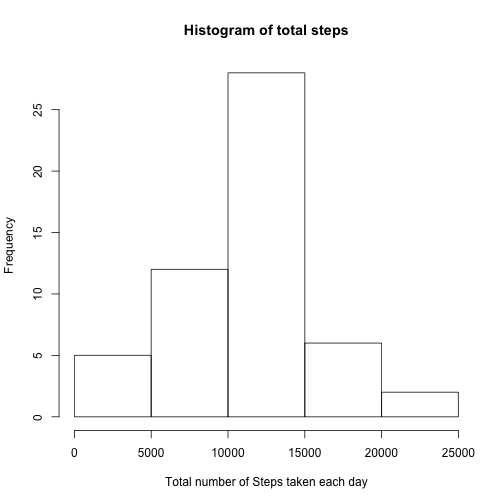

```r
hist(activity1$steps, xlab = "Total number of Steps taken each day", main = "Histogram of total steps")
```

1. Here is the code to calculate mean number of steps taken per day.

```r
activity.mean <- aggregate(steps ~ date, activity, mean)
activity.mean
```

```
##          date      steps
## 1  2012-10-02  0.4375000
## 2  2012-10-03 39.4166667
## 3  2012-10-04 42.0694444
## 4  2012-10-05 46.1597222
## 5  2012-10-06 53.5416667
## 6  2012-10-07 38.2465278
## 7  2012-10-09 44.4826389
## 8  2012-10-10 34.3750000
## 9  2012-10-11 35.7777778
## 10 2012-10-12 60.3541667
## 11 2012-10-13 43.1458333
## 12 2012-10-14 52.4236111
## 13 2012-10-15 35.2048611
## 14 2012-10-16 52.3750000
```

[output cut: 39 more lines]

Here is the code to calculate median number of steps taken per day.

```r
activity.median <- aggregate(steps ~ date, activity, median)
activity.median
```

```
##          date steps
## 1  2012-10-02     0
## 2  2012-10-03     0
## 3  2012-10-04     0
## 4  2012-10-05     0
## 5  2012-10-06     0
## 6  2012-10-07     0
## 7  2012-10-09     0
## 8  2012-10-10     0
## 9  2012-10-11     0
## 10 2012-10-12     0
## 11 2012-10-13     0
## 12 2012-10-14     0
## 13 2012-10-15     0
## 14 2012-10-16     0
```

[output cut: 39 more lines]

## Average daily activity pattern

1. Calculate daily activity pattern.

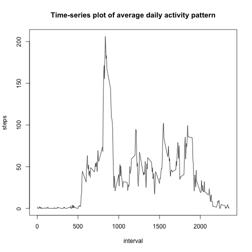

```r
activity.int <- aggregate(steps ~ interval, activity, mean)
with(activity.int, plot(interval, steps, type = "l", main = "Time-series plot of average daily activity pattern"))
```

1. Code to calculate the 5-minute interval that contains maximum number of steps on average across all the days in the dataset.

```r
max.int <- activity.int[which.max(activity.int$steps), ]
x <- max.int$interval
```

Interval 835 contains maximum number of steps n average across all the days in the dataset.

## Imputing missing values

1. Calculate the total number of missing value in the dataset.

```r
na.data <- sum(is.na(activity))
```

Data contains 2304 missing values.

1. Fill missing values with the mean value for the 5-minute interval

This code imputes missing values with the mean for that 5-minute interval.

```r
library(zoo)
impute.activity <- activity
impute.activity$steps <- na.aggregate(impute.activity$steps, by = impute.activity$interval)
head(impute.activity)
```

```
##       steps       date interval
## 1 1.7169811 2012-10-01        0
## 2 0.3396226 2012-10-01        5
## 3 0.1320755 2012-10-01       10
## 4 0.1509434 2012-10-01       15
## 5 0.0754717 2012-10-01       20
## 6 2.0943396 2012-10-01       25
```

1. With the abovementioned code, *impute.activity* - a new data set, is created that is equal to the original dataset with the missing data filled in.
2. This code generates a histogram for the imputed dataset.

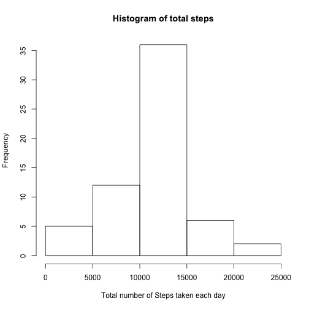

```r
impute.activity1 <- aggregate(steps ~ date, impute.activity, sum)
hist(impute.activity1$steps, xlab = "Total number of Steps taken each day", main = "Histogram of total steps")
```

Following code calculates mean number of steps taken per day.

```r
imputed.mean <- aggregate(steps ~ date, impute.activity, mean)
imputed.mean
```

```
##          date      steps
## 1  2012-10-01 37.3825996
## 2  2012-10-02  0.4375000
## 3  2012-10-03 39.4166667
## 4  2012-10-04 42.0694444
## 5  2012-10-05 46.1597222
## 6  2012-10-06 53.5416667
## 7  2012-10-07 38.2465278
## 8  2012-10-08 37.3825996
## 9  2012-10-09 44.4826389
## 10 2012-10-10 34.3750000
## 11 2012-10-11 35.7777778
## 12 2012-10-12 60.3541667
## 13 2012-10-13 43.1458333
## 14 2012-10-14 52.4236111
```

[output cut: 47 more lines]

Following code calculates median number of steps taken per day.

```r
imputed.median <- aggregate(steps ~ date, impute.activity, median)
imputed.median
```

```
##          date    steps
## 1  2012-10-01 34.11321
## 2  2012-10-02  0.00000
## 3  2012-10-03  0.00000
## 4  2012-10-04  0.00000
## 5  2012-10-05  0.00000
## 6  2012-10-06  0.00000
## 7  2012-10-07  0.00000
## 8  2012-10-08 34.11321
## 9  2012-10-09  0.00000
## 10 2012-10-10  0.00000
## 11 2012-10-11  0.00000
## 12 2012-10-12  0.00000
## 13 2012-10-13  0.00000
## 14 2012-10-14  0.00000
```

[output cut: 47 more lines]

Imputed values don't change the general pattern of the histogram. However, median values are significantly affected.

## Differences in activity patterns between weekdays and weekends

1. Create a factor variable in the dataset with two levels – “weekday” and “weekend”.

```r
library(timeDate)
library(dplyr)
week.activity <- activity %>% mutate(weekday = isWeekday(activity$date))
head(week.activity)
```

```
##   steps       date interval weekday
## 1    NA 2012-10-01        0    TRUE
## 2    NA 2012-10-01        5    TRUE
## 3    NA 2012-10-01       10    TRUE
## 4    NA 2012-10-01       15    TRUE
## 5    NA 2012-10-01       20    TRUE
## 6    NA 2012-10-01       25    TRUE
```

```r
week.activity <- transform(week.activity, weekday = factor(weekday))
```

The code above creates a logical factor variable indicating weekdays (TRUE) and weekends (FALSE).

1. Here is the code to generate lattice plot showing differences in activity patterns between weekdays and weekends.

[figure not shown]

```r
library(lattice)
xyplot(steps ~ interval | weekday, data = week.activity, layout = c(1, 2), type = "l", strip = strip.custom(factor.levels = c("Weekday", "Weekend")))
```